# Jordan Lake Reservoir Model

Part8: Management scenarios

Smitom Borah

04/29/2023

Time required to run the entire notebook: ~ 18 hrs

# 1 Motivation

In this notebook, we simulate the future trends of TP in water and sediment columns under different management scenarios under RCP 8.5.

# 2 Loading packages

Following packages were used in this notebook.

```r
# Clearing the working environment----
cat("\014"); rm(list=ls(all=TRUE)); graphics.off()
# Start timer
Start_timer8 <- Sys.time()

# Loading the packages----
if (!require("pacman")) install.packages("pacman") ;
pacman::p_load(shinyjs,threejs,xlsx,minpack.lm,MuMIn,lme4,penalized,zoo,RColorBrewer,gridExtra,rowr,stringi,optimx,purrrlyr,Hmisc,leaps,caret,magrittr,plotly,remotes,RcppRoll,suncalc,adaptMCMC,TTR, truncnorm, readxl,lubridate, data.table,deSolve,zoo,tidyverse)
```

```r
library(lubridate)
library(randomForest)

# Functions
## Function to determine the season of the year
Season <- function(Date){
  # Date -> date vector

  # Creating a month vector
  Mo <- month(Date)
  season <- rep(NA, length(Mo))
  for (i in 1:length(Mo)) {
    if (Mo[i] %in% c(1,2,3)){
      season[i] <- "Winter"
    } else if (Mo[i] %in% c(4,5,6)){
      season[i] <- "Spring"
    } else if (Mo[i] %in% c(7,8,9)){
      season[i] <- "Summer"
    } else {
      season[i] <- "Fall"
    }

  }
  return(season)
}
## test run
# Season(as.Date("2018-10-12", format = "%Y-%m-%d"))

## function to calculate 35days moving average of a column
MA35func <- function(x){
  # x -> column whose moving average needs to be calculated

  return(rollmean(x, 35, fill = NA, align = "right"))

}

## function to calculate 14days moving average of a column
MA14func <- function(x){
  # x -> column whose moving average needs to be calculated

  return(rollmean(x, 14, fill = NA, align = "right"))

}

## function to create bottom to surface P ratios in the forcast loop
### Cannot be tested outside the loop
Pratios.fun <- function(smplyrvec, bt.df = AvgT_85.35ma.d, st.df = AvgT_85.14ma.d, PinpDFall.df = PinpDFall){
  #----------------------------------------------------------------------
  # Argument list:
  # smplyrvec ->  vector of sampled historical years for historical data in the prediction years
  # bt.df -> data frame of daily 35d moving average of air temperature from 32 GCFs (bottom temp)
  # st.df -> data frame of daily 35d moving average of air temperature from 32 GCFs (surface temp)
  #----------------------------------------------------------------------

  WS.df <- WS.func(Smpleyr = smplyrvec)

  RFfactorsDf <- data.frame(Date =  WS.df$Date,
                            Average.Wind.Speed.ms =  WS.df$`Average Wind Speed (ms)`)

  RFfactorsDf <- merge (RFfactorsDf,
                          bt.df[,c(1,sample(seq(5,36), size = 1))],
                          by = "Date", all.x = T)

  RFfactorsDf <- merge (RFfactorsDf,
                          st.df[,c(1,sample(seq(5,36), size = 1))],
                          by = "Date", all.x = T)

  hypo.PinpDFall <- PinpDFall.df[,c("Date", "H2m", "H3m", "H4m")]

  # Create DateTime object for entire duration
  hypo.p.o.r <- data.frame(Date = seq(as.Date(date.cali.daily[1]), as.Date(date.pred.daily[length(date.pred.daily)]),  by = "1 day"))

   # merging
  hypo.PinpDFall <- merge(hypo.p.o.r, hypo.PinpDFall, by = "Date", all.x = T)

  # Filling the daily values from the monthly values
  hypo.PinpDFall <- na.locf(na.locf(hypo.PinpDFall), fromLast = T)

  # Segment 2
  RFfactorsDf2 <- merge(hypo.PinpDFall[,c("Date", "H2m")], RFfactorsDf, by = "Date", all.x = T)

  ## adding surface sampling, segment and month details
  RFfactorsDf2 <- RFfactorsDf2 %>% mutate(Depth_surface = rep(1.5, nrow(RFfactorsDf2)),
                                          Month = month(Date),
                                          Segment = rep(2, nrow(RFfactorsDf2)))
  ## Changing the column names
  col.names <- c("Date", "Depth_Bottom", "Average.Wind.Speed.ms", "BottomTemp", "SurfaceTemp", "Depth_surface", "Month", "Segment" )
  colnames(RFfactorsDf2) <- col.names

  ## Rearranging the terms
  rearr.vec <- c("Date","Average.Wind.Speed.ms","BottomTemp","SurfaceTemp", "Month", "Depth_surface", "Depth_Bottom", "Segment")
  RFfactorsDf2 <- RFfactorsDf2[,rearr.vec]

  # Segment 3
  RFfactorsDf3 <- merge(hypo.PinpDFall[,c("Date", "H3m")], RFfactorsDf, by = "Date", all.x = T)

  ## adding surface sampling, segment and month details
  RFfactorsDf3 <- RFfactorsDf3 %>% mutate(Depth_surface = rep(1.5, nrow(RFfactorsDf3)),
                                          Month = month(Date),
                                          Segment = rep(3, nrow(RFfactorsDf3)))
  ## Changing the column names
  colnames(RFfactorsDf3) <- col.names

  ## Rearranging the terms
  RFfactorsDf3 <- RFfactorsDf3[,rearr.vec]

  # Segment 4
  RFfactorsDf4 <- merge(hypo.PinpDFall[,c("Date", "H4m")], RFfactorsDf, by = "Date", all.x = T)

  ## adding surface sampling, segment and month details
  RFfactorsDf4 <- RFfactorsDf4 %>% mutate(Depth_surface = rep(1.5, nrow(RFfactorsDf4)),
                                          Month = month(Date),
                                          Segment = rep(4, nrow(RFfactorsDf4)))
  ## Changing the column names
  colnames(RFfactorsDf4) <- col.names

  ## Rearranging the terms
  RFfactorsDf4 <- RFfactorsDf4[,rearr.vec]

  # Rbs values
  Rbs2 <- data.frame(Date = RFfactorsDf2$Date, Rbs2 = predict(BoSuP.rf, newdata = select(RFfactorsDf2, -Date))) %>%
    mutate(Month = month(Date),
           Year = year(Date)) %>%
    group_by(Year,Month) %>%
    summarise(Rbs2 = mean(Rbs2))

  Rbs3 <- data.frame(Date = RFfactorsDf3$Date, Rbs3 = predict(BoSuP.rf, newdata = select(RFfactorsDf3, -Date))) %>%
    mutate(Month = month(Date),
           Year = year(Date)) %>%
    group_by(Year,Month) %>%
    summarise(Rbs3 = mean(Rbs3))

  Rbs4 <- data.frame(Date = RFfactorsDf4$Date, Rbs4 = predict(BoSuP.rf, newdata = select(RFfactorsDf4, -Date))) %>%
    mutate(Month = month(Date),
           Year = year(Date)) %>%
    group_by(Year,Month) %>%
    summarise(Rbs4 = mean(Rbs4))

  return(list(Rbs2, Rbs3, Rbs4))
}
```

# 3 General Plotting specification

To maintain the consistency in the plots developed in this notebook, we create a ggplot object to store the basic specification for each plot.

```r
# General plot specification
plot_basics <- ggplot()+
  theme_bw()+
  theme(legend.background = element_blank(),
        panel.grid.major = element_blank(),
        panel.grid.minor = element_blank(),
        legend.text.align = 0,
        text = element_text(size = 10),
        legend.text = element_text(size = 10, color = "black"),
        axis.title = element_text(size = 10, color = "black"),
        axis.text = element_text(size = 10, color = "black"))
```

# 4 Loading the Random Forest Model

```r
# loading the RWorkspace of JLPMv016p004.Rmd
load("RWorkSpaces/JLPMv016p004_1.RData")

# Check the Random Forest model
BoSuP.rf
```

```
Call:
 randomForest(formula = BoSuP ~ ., data = select(SegPfac1, -Date),      mtry = 3, ntree = 1000, importance = TRUE, na.action = na.omit)
               Type of random forest: regression
                     Number of trees: 1000
No. of variables tried at each split: 3

          Mean of squared residuals: 1.318645
                    % Var explained: 34.81
```

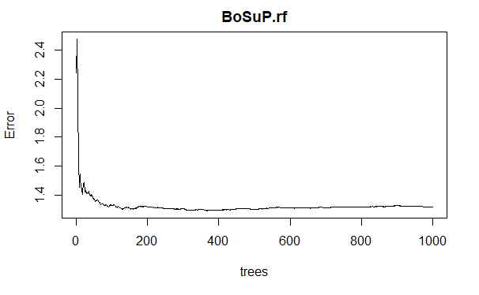

```r
plot(BoSuP.rf)
```

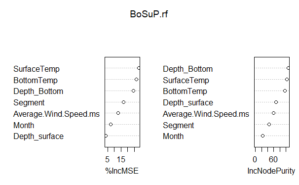

```r
varImpPlot(BoSuP.rf)
```

```r
# Coefficient of determination
print(paste0("Coefficient of determination: ", VarExp(BoSuP.rf$predicted, BoSuP.rf$y)))
```

```
[1] "Coefficient of determination: 0.348"
```

# 5 Calibration and forecast period

```r
# Daily period of record and prediction----
## Daily period of record
date.cali.daily <- floor_date(seq(ymd('1983-01-01'),
                                  ymd('2018-12-31'),
                                  by = 'day'),
                        unit = "day")

## Period of prediction
date.pred.daily <- floor_date(seq(ymd('2019-01-01'),
                                  ymd('2090-12-31'),
                                  by = 'day'),
                        unit = "day")


# Monthly eriod of record and prediction----
## Period of record
date_cali <- floor_date(seq(ymd('1983-01-01'),ymd('2018-12-01'), by = 'month'), unit = "month")

## Period of prediction
date_scen <- floor_date(seq(ymd('2019-01-01'),ymd('2090-12-01'), by = 'month'), unit = "month")
```

# 6 Wind speed

We used the the randomly sampled windspeed data from historical records (1999-2018) to create future simulations. Here. we develop a function to create a data frame of windspeed in the future forecasting loop.

```r
# year range for historical simulation
st.year <- 1999 # Start year
ed.year <- 2018 # end year

# number of years in prediction
st.pred.yr <- 2019
ed.pred.yr <- 2090
Tot.yrs <- ed.pred.yr-st.pred.yr+1

# All the historial years
hist.allyr <- seq(st.year, ed.year, by = 1)

# prediction years
pred.Actyr <- seq(st.pred.yr,ed.pred.yr,1)

# # Sampling the years for future projection
set.seed(123)
pred.allyr <- sample(hist.allyr,Tot.yrs,replace = T )

## Converting the observed wind speed into m/s
RDU_wind$`Average Wind Speed (ms)` <- RDU_wind$`Average Wind Speed (mph)`*0.447

WS.func <- function(obsWS = RDU_wind,
                    histyr = hist.allyr,
                    predyr = pred.Actyr,
                    Smpleyr = pred.allyr,
                    predDate.d = date.pred.daily){
  ##-------------------------------------------------------------------------
  ## Argument list
  ## obsWS: Observed wind speed
  ## histyr: vector of historical years, most likely 1999 to 2018
  ## predyr: vector of prediction years, most likely 2019 to 2090
  ## Smpleyr: vector of sampled historical years for historical data in the prediction years
  ## predDate.d : vector of daily prediction dates, most likely 01/01/2019 to 12/31/2099
  ##-------------------------------------------------------------------------

  pred.WSdf <- data.frame()
  for (ii in 1:Tot.yrs){

    tdf <- RDU_wind[which(year(RDU_wind$Date)%in%histyr),] %>%
      mutate(Year = year(Date))
    tdf <- tdf[which(tdf$Year %in%Smpleyr[ii] ),]


    if(predyr[ii]%%4!=0 && Smpleyr[ii]%%4==0){
      tdf <- tdf[-which(tdf$Date==as.Date(paste0("2/29/",Smpleyr[ii]), format = "%m/%d/%Y")),]
    }

    if (predyr[ii]%%4==0 && Smpleyr[ii]%%4!=0){
      ExtraDay <- data.frame(Date = as.Date(paste0("2/28/",Smpleyr[ii]), format = "%m/%d/%Y"),
                             `Average Wind Speed (mph)` = NA,
                             `Maximum Wind Speed (mph)` = NA,
                             `Average Wind Speed (ms)` = NA,
                             Year = Smpleyr[ii])
      tdf[nrow(tdf)+1,] <- ExtraDay
      tdf %<>% arrange(tdf$Date)
    }
    pred.WSdf %<>%bind_rows(.,tdf)
  }

  # Data tidying
  ## Changing the date and years
  pred.WSdf$Date <- predDate.d
  pred.WSdf$Year <- year(pred.WSdf$Date)

  ## combining the historical and predicted windspeed
  WindSpeed <- obsWS %>% mutate(Year = year(Date))
  WindSpeed <- rbind(WindSpeed, pred.WSdf)

  ## Imputing the missing data with previous data points
  WindSpeed <- na.locf(na.locf(WindSpeed), fromLast = T)

  return(WindSpeed)

}

# Checking the function
WindSpeed <- WS.func()
```

# 7 Air temperature

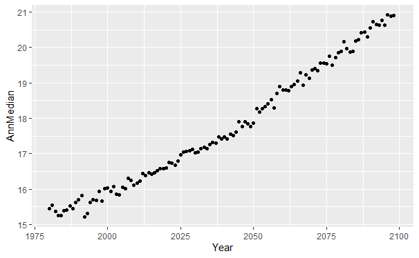

```r
# Loading minimum temperature data----
## 1980-2050
MinT_85_raw1 <- read.csv("DataFiles/Loca_Temp_min_85.csv", header = TRUE)

### Adding date and median temperature column for quick plot
MinT_85_1 <- MinT_85_raw1 %>%
  mutate(Date = as.Date(paste0(Year,"/",Month,"/",Day)),
         MedianT = apply(MinT_85_raw1[,c(4:35)], 1, median))

## 2051-2099
MinT_85_raw2 <- read.csv("DataFiles/Loca_Temp_min_85_20512099.csv", header = FALSE)

### Adding column names
colnames(MinT_85_raw2) <- c("Year", "Month", "Day", paste0("Temp",c(1:32)))

### making all the temperature data numeric
MinT_85_raw2[,4:35] <- as.numeric(unlist(MinT_85_raw2[,4:35]))

### Adding date and median temperature column for quick plot
MinT_85_2 <- MinT_85_raw2 %>%
  mutate(Date = as.Date(paste0(Year,"/",Month,"/",Day), format = "%Y/%m/%d"),
         MedianT = apply(MinT_85_raw2[,c(4:35)], 1, median))

## combining the two data frames
MinT_85 <- rbind(MinT_85_1,MinT_85_2)

# Loading maximum temperature data----
## 1980-2050
MaxT_85_raw1 <- read.csv("DataFiles/Loca_Temp_max_85.csv", header = TRUE)

### Adding date and median temperature column for quick plot
MaxT_85_1 <- MaxT_85_raw1 %>%
  mutate(Date = as.Date(paste0(Year,"/",Month,"/",Day)),
         MedianT = apply(MaxT_85_raw1[,c(4:35)], 1, median))

## 2050-2099
MaxT_85_raw2 <- read.csv("DataFiles/Loca_Temp_max_85_20512099.csv", header = FALSE)

### Adding column names
colnames(MaxT_85_raw2) <- c("Year", "Month", "Day", paste0("Temp",c(1:32)))

### making all the temperature data numeric
MaxT_85_raw2[,4:35] <- as.numeric(unlist(MaxT_85_raw2[,4:35]))

### Adding date and median temperature column for quick plot
MaxT_85_2 <- MaxT_85_raw2 %>%
  mutate(Date = as.Date(paste0(Year,"/",Month,"/",Day)),
         MedianT = apply(MaxT_85_raw2[,c(4:35)], 1, median))

# combining the two data frames
MaxT_85 <- rbind(MaxT_85_1,MaxT_85_2)

# daily temperature
AvgT_85 <- bind_rows(MinT_85, MaxT_85) %>%
  group_by(Date) %>%
  summarise_all(list(mean))

# Plotting the moving median average temperature
AvgT_85 %>% group_by(Year) %>% summarise(AnnMedian = mean(MedianT)) %>% ggplot()+
  geom_point(aes(x = Year, y = AnnMedian))
```

```r
# 5 week moving average
AvgT_85.35ma.d <- AvgT_85 %>% mutate_at(c(5:36), MA35func) %>% drop_na()

# Data tidying
AvgT_85.35ma.d <- AvgT_85.35ma.d[,c(1:36)]
colnames(AvgT_85.35ma.d) <- c("Date", "Year", "Month", "Day", paste0("Temp.35dMA.",c(1:32)))

# 2 week moving average
AvgT_85.14ma.d <- AvgT_85 %>% mutate_at(c(5:36), MA14func) %>% drop_na()

# Data tidying
AvgT_85.14ma.d <- AvgT_85.14ma.d[,c(1:36)]
colnames(AvgT_85.14ma.d) <- c("Date", "Year", "Month", "Day", paste0("Temp.14dMA.",c(1:32)))
```

# 8 Water temperature

We developed a linear model to predict the bottom water temperature from the air temperature (2m above surface). Based on our preliminary investigations, we found the 5week moving average yielded the best results.The linear model is as follows:

$$Bottom\ water\ temperature = 0.89\times
(35day m.a.\ air temperature)+2.58$$

```r
# prediction water temperature data
predWtrT85.35ma.d <- AvgT_85.35ma.d[which(AvgT_85.35ma.d$Year%in%c(2019:2099)),]

# Applying the linear progrssion model
predWtrT85.35ma.d[,c(5:36)] <- 0.89*predWtrT85.35ma.d[,c(5:36)]+2.58
tmp85_dat  <- predWtrT85.35ma.d %>% group_by(Year, Month) %>%
  summarise_at(.,.vars = colnames(predWtrT85.35ma.d)[5:36], mean) %>% as.data.frame()

tmp85_dat <- tmp85_dat %>%
  mutate(Art_date = as.Date(paste0(Year,"/",Month, "/01")))

## getting only temperature between 2019-2090
tmp85_dat <- tmp85_dat[which(tmp85_dat$Art_date %in% date_scen),]

## Adding columns for median, min and max temperature
tmp85_dat <- tmp85_dat %>% mutate(Median_temp = apply(tmp85_dat[,3:34], 1, median),
                                  min_temp = apply(tmp85_dat[,3:34], 1, min),
                                  max_temp = apply(tmp85_dat[,3:34], 1, max))
```

# 9 Average Mass in the historical years

Let us calculate the average mass in each segment in the historical years. This information is useful for future year P concentration predictions.

```r
# average Mass in each segments
MassFlows <- read.csv("OutputFiles/MassFlows.csv")

## Segment 1
meanM1 <- mean(MassFlows[which(MassFlows$year %in% c(1999,2018)),]$M1)

## Segment 2
meanM2 <- mean(MassFlows[which(MassFlows$year %in% c(1999,2018)),]$M2)

## Segment 3
meanM3 <- mean(MassFlows[which(MassFlows$year %in% c(1999,2018)),]$M3)

## Segment 4
meanM4 <- mean(MassFlows[which(MassFlows$year %in% c(1999,2018)),]$M4)

# Quick view
AvgMoP.df<- data.frame(Segment = c(1,2,3,4), Avg.P.Mass_kg_mo = c(meanM1, meanM2, meanM3, meanM4))
AvgMoP.df
```

| Segment | Avg.P.Mass_kg_mo |
| --- | --- |
| 1 | 1850.067 |
| 2 | 3736.194 |
| 3 | 5534.170 |
| 4 | 4302.757 |

# 10 Combination 1: No external loading reduction + No internal loading reduction

## 10.1 Inputs

In this section, we specify the inputs required to run the model

```r
# Number of posterior parameter samples
N <- 1000
```

```r
# Percentage reduction in external P loading
exPH00 <- -0

# percentage of Sediment P release allowed
inPH00 <- 100

# Loading the First-order workspace
load("RWorkSpaces/JLPMv016p001_1.RData")
rm(Rbs2); rm(Rbs3); rm(Rbs4)

# Inputs
Popt_par <- opt_prm
PinpDF <- RoutMOdin[,!colnames(RoutMOdin) %in% c("...1")]
PinpDF <- RoutMOdin
Pinp <- RoutMOdin %>% creaInp(.,tlim=nrow(.))
Pico <- Const_lis
Pico$timestep <- 1:length(Pinp$A1t)
Pico$vs_scal <- vs_scal
Pico$par_scal <- par_scal

# Changing the Date of PinpDF
PinpDF$Date <- as.Date(paste0(PinpDF$mo,"/1/",PinpDF$year), format = "%m/%d/%Y")

# Adding the hypolimnion middepths
# loading the monthly hypolimnetic depths data
hypo.midDepth.raw <- read_excel("DataFiles/HypolimnionCalcs.xlsx",
                                sheet = "Sheet1", range = "A2:Y434")%>%
  rename(.,
         H1m = `H1 m...22`,
         H2m = `H2 m...23`,
         H3m = `H3 m...24`,
         H4m = `H4 m...25`)

# Only segments 2-4
hypo.midDepth <- hypo.midDepth.raw[,c("start_d", "H2m", "H3m", "H4m")]

# renaming a column
colnames(hypo.midDepth)[1] <- "Date"
hypo.midDepth$Date <- as.Date(hypo.midDepth$Date)

# Adding the hypolimnion mid-depths to PinpDF
PinpDF <- merge(PinpDF,hypo.midDepth,by = "Date", all.x = T )


# Setting seed
set.seed(500)

# sampling set of posterior samples
postPsmpl <- RAM$samples[sample(seq((nrow(RAM$samples)-25000),nrow(RAM$samples)), N, replace = F),]


# Separating the observations
Pobs <- obs %>% transmute(cale_date=myd(paste0(as.character(ym),"-1")),
                          TPugL = obs,variable)

# Check for segments
all_seg <- Pobs %>% pull(variable) %>% unique # should be 4 : "C1","C2","C3" and "C4"

# Loading the functions file
source("Pmodels/JLPMfunv16p008.R")

# Projection years
yrs_prj <- date_scen %>% year %>% unique %>% length()

# Setting up the dataframe to hold all the iteration in one space
## For Confidence interval
meanDFH00 <- tibble(sce_j=rep(exPH00),
                 par_i=seq(1:N),
                 Psim=vector("list",N))

## For Prediction interval
predDFH00 <- meanDFH00
```

## 10.2 Generating future projections

```r
start.time = Sys.time()

for (i in 1:N){

  # Selecting the nutrient scenario and parameter set
  EP_red <-  meanDFH00[i, "sce_j"][[1]]
  parPi <- postPsmpl[meanDFH00[i, "par_i"][[1]],]


  # Sampling historical hydrology
  rand_yr <- sample(hist.allyr,Tot.yrs,replace = T )

  PinpFut <- data.frame()
  for (ii in 1:yrs_prj){
    tdf <- PinpDF %>% dplyr::filter(year%in%rand_yr[ii])
    PinpFut %<>%bind_rows(.,tdf)
  }

  PinpFut$t <- seq(1,nrow(PinpFut))

  # change input concentrations according to scenario
  PinpFut %<>% dplyr::mutate_at(vars(matches("C[0-9]in",ignore.case=F)),
                                 .funs =funs(. * (EP_red+100)/100))

  PinpFut$Temperature <- unlist(tmp85_dat[,sample(seq(3,34), size = 1)],
                                use.names=FALSE)

  # Getting the dates right
  PinpFut$Date <- as.Date(date_scen)

  # Combining calibration and prediction datasets together
  PinpDFall <- PinpDF %>% as_tibble() %>% bind_rows(.,PinpFut) %>%
    rowid_to_column(., "ro")

  # Dataset to calculate the bottom to surface P ratios

  ## test of Pratios.fun
  ## x <- Pratios.fun(rand_yr)

  BotSutPrat <- Pratios.fun(smplyrvec = rand_yr)


  Pico$Rbs2 <- BotSutPrat[[1]]$Rbs2
  Pico$Rbs3 <- BotSutPrat[[2]]$Rbs3
  Pico$Rbs4 <- BotSutPrat[[3]]$Rbs4

  # Model run for calibration part
  Pico_tmp1 <- Pico
  Pico_tmp2 <- Pico

  # correcting the order of the PinpDFall data set
  PinpDFall$Date <- as.Date(PinpDFall$Date, format = "%Y-%m-%d")
  PinpDFall <- PinpDFall[order(PinpDFall$Date),]

  # Accounting for imaginary volume addition/removal in future years
  PinpDFall <- PinpVolBal.fun()

  # adding a internal P reduction factor
  IntPred <- c(rep(1,nrow(PinpDF)), rep(inPH00/100, nrow(PinpDFall)-nrow(PinpDF)))

  PinpDFall <- PinpDFall %>% mutate(ipr = IntPred)

  # Correcting the years
  PinpDFall$year <- year(PinpDFall$Date)

  # Arranging the calibration dataset
  PinpCaSc1 <- PinpDFall[(1:(nrow(PinpDF)+1)),] %>% creaInp(.,tlim=nrow(.))
  Pico_tmp1$timestep <- 1:length(PinpCaSc1$A1t)
  Pico_tmp1$Rbs2 <- Pico_tmp1$Rbs2[1:length(PinpCaSc1$A1t)]
  Pico_tmp1$Rbs3 <- Pico_tmp1$Rbs3[1:length(PinpCaSc1$A1t)]
  Pico_tmp1$Rbs4 <- Pico_tmp1$Rbs4[1:length(PinpCaSc1$A1t)]

  PmeanRes1 <- mod_wrap_pred_v3(inp_dat=PinpCaSc1,
                               FixInp_lis=Pico_tmp1,
                               CalPar=parPi) %>%
    dplyr::select(matches("C1|C.sur"),M1,M2,M3, M4,S1,S2,S3,S4,temperature) %>%
    `colnames<-`(substring(colnames(.),1,2)) %>%
    add_column(.,cale_date=c(date_cali, date_scen[1]))

   # Model run for the future projections
  PinpCaSc2 <- PinpDFall[((nrow(PinpDF)+1):nrow(PinpDFall)),] %>% creaInp(.,tlim=nrow(.))
  Pico_tmp2$timestep <- 1:length(PinpCaSc2$A1t)
  Pico_tmp2$Rbs2 <- BotSutPrat[[1]]$Rbs2[(nrow(PinpDF)+1):nrow(PinpDFall)]
  Pico_tmp2$Rbs3 <- BotSutPrat[[2]]$Rbs3[(nrow(PinpDF)+1):nrow(PinpDFall)]
  Pico_tmp2$Rbs4 <- BotSutPrat[[3]]$Rbs4[(nrow(PinpDF)+1):nrow(PinpDFall)]

  Pico_tmp2$M1init <- AvgMoP.df$Avg.P.Mass_kg_mo[1]
  Pico_tmp2$M2init <- AvgMoP.df$Avg.P.Mass_kg_mo[2]
  Pico_tmp2$M3init <- AvgMoP.df$Avg.P.Mass_kg_mo[3]
  Pico_tmp2$M4init <- AvgMoP.df$Avg.P.Mass_kg_mo[4]
  Pico_tmp2$S1init <- PmeanRes1$S1[nrow(PmeanRes1)]
  Pico_tmp2$S2init <- PmeanRes1$S2[nrow(PmeanRes1)]
  Pico_tmp2$S3init <- PmeanRes1$S3[nrow(PmeanRes1)]
  Pico_tmp2$S4init <- PmeanRes1$S4[nrow(PmeanRes1)]

  parPi["S1fac"] <- 1

  PmeanRes2 <- mod_wrap_pred_v3(inp_dat=PinpCaSc2,
                               FixInp_lis=Pico_tmp2,
                               CalPar=parPi) %>%
    dplyr::select(matches("C1|C.sur"),M1,M2,M3, M4, S1,S2,S3,S4,temperature) %>%
    `colnames<-`(substring(colnames(.),1,2)) %>%
    add_column(.,cale_date=c(date_scen))

  PmeanRes <- rbind(PmeanRes1[1:(nrow(PmeanRes1)-1),],PmeanRes2)


  PmeanRes <- PmeanRes %>% mutate(S1res = (parPi["Rs"]/100)*S1*(parPi["ThetaR"]^(te-20)),
                                  S2res = (parPi["Rs"]/100)*S2*(parPi["ThetaR"]^(te-20)),
                                  S3res = (parPi["Rs"]/100)*S3*(parPi["ThetaR"]^(te-20)),
                                  S4res = (parPi["Rs"]/100)*S4*(parPi["ThetaR"]^(te-20)),
                                  Sconc = (S1+S2+S3+S4)/(49.02*10^3),
                                  Sres = (S1res+S2res+S3res+S4res)/(49.02*10^3))

  PpredRes <- PmeanRes %>%  # only adds observ error to Conc
    mutate_each(funs(sysanal.boxcox(., l1,l2)),-c(cale_date)) %>% # transform
    mutate_each(funs(.+rnorm(length(.),0,parPi["sy"])),-c(cale_date)) %>%  # add P error
    mutate_each(funs(sysanal.boxcox.inv(., l1,l2)),-c(cale_date)) # back transform


  meanDFH00[i,"Psim"][[1]] <- PmeanRes %>% list
  predDFH00[i,"Psim"][[1]] <- PpredRes %>% list


  svMisc::progress((i/N)*100)
  Sys.sleep(0.1)
  if (i == N) message("Done!")
}
```

Time taken to run the above code chunk:

```r
# Total tile taken
time.taken
```

[output not shown]

## 10.3 TP projections

```r
# test
# x <- PI_rangefunc("C1")

CI_TP1_H00 <- PI_rangefunc("C1")
```

## 10.4 Sediment P

```r
sedP_H00 <- PI_rangefunc("Sconc")
```

# 11 Temporary save

```r
# Saving the file
# Saving the file [06-05-2023 04:30 PM]
save.image("RWorkSpaces/JLPMv016p008_tmp1.RData")
```

# 12 Combination 2: 50% external loading reduction + No internal loading reduction

## 12.1 Inputs

In this section, we specify the inputs required to run the model

```r
# Percentage reduction in external P loading
exPH500 <- -50

# percentage of Sediment P release allowed
inPH500 <- 100

# Loading the First-order workspace
load("RWorkSpaces/JLPMv016p001_1.RData")
rm(Rbs2); rm(Rbs3); rm(Rbs4)

# Inputs
Popt_par <- opt_prm
PinpDF <- RoutMOdin[,!colnames(RoutMOdin) %in% c("...1")]
PinpDF <- RoutMOdin
Pinp <- RoutMOdin %>% creaInp(.,tlim=nrow(.))
Pico <- Const_lis
Pico$timestep <- 1:length(Pinp$A1t)
Pico$vs_scal <- vs_scal
Pico$par_scal <- par_scal

# Changing the Date of PinpDF
PinpDF$Date <- as.Date(paste0(PinpDF$mo,"/1/",PinpDF$year), format = "%m/%d/%Y")

# Adding the hypolimnion middepths
# loading the monthly hypolimnetic depths data
hypo.midDepth.raw <- read_excel("DataFiles/HypolimnionCalcs.xlsx",
                                sheet = "Sheet1", range = "A2:Y434")%>%
  rename(.,
         H1m = `H1 m...22`,
         H2m = `H2 m...23`,
         H3m = `H3 m...24`,
         H4m = `H4 m...25`)

# Only segments 2-4
hypo.midDepth <- hypo.midDepth.raw[,c("start_d", "H2m", "H3m", "H4m")]

# renaming a column
colnames(hypo.midDepth)[1] <- "Date"
hypo.midDepth$Date <- as.Date(hypo.midDepth$Date)

# Adding the hypolimnion mid-depths to PinpDF
PinpDF <- merge(PinpDF,hypo.midDepth,by = "Date", all.x = T )


# Setting seed
set.seed(500)
# sampling set of posterior samples
postPsmpl <- RAM$samples[sample(seq((nrow(RAM$samples)-25000),nrow(RAM$samples)), N, replace = F),]


# Separating the observations
Pobs <- obs %>% transmute(cale_date=myd(paste0(as.character(ym),"-1")),
                          TPugL = obs,variable)

# Check for segments
all_seg <- Pobs %>% pull(variable) %>% unique # should be 4 : "C1","C2","C3" and "C4"

# Loading the functions file
source("Pmodels/JLPMfunv16p008.R")

# Projection years
yrs_prj <- date_scen %>% year %>% unique %>% length()

# Setting up the dataframe to hold all the iteration in one space
## For Confidence interval
meanDFH500 <- tibble(sce_j=rep(exPH500),
                 par_i=seq(1:N),
                 Psim=vector("list",N))

## For Prediction interval
predDFH500 <- meanDFH500
```

```r
# Total tile taken
time.taken
```

```
Time difference of 3.04333 hours
```

## 12.3 TP projections

```r
# test
# x <- PI_rangefunc("C1")

CI_TP1_H500 <- PI_rangefunc("C1", meanDF = meanDFH500, predDF = predDFH500)
```

## 12.4 Sediment P

```r
sedP_H500 <- PI_rangefunc("Sconc", meanDF = meanDFH500, predDF = predDFH500)
```

# 13 Temporary save

```r
# Saving the file [06-05-2023 04:30 PM]
save.image("RWorkSpaces/JLPMv016p008_tmp1.RData")
```

# 14 Combination 3: 50% external loading reduction + 50% internal loading reduction

## 14.1 Inputs

In this section, we specify the inputs required to run the model

```r
# Percentage reduction in external P loading
exPH5050 <- -50

# percentage of Sediment P release allowed
inPH5050 <- 50

# Loading the First-order workspace
load("RWorkSpaces/JLPMv016p001_1.RData")
rm(Rbs2); rm(Rbs3); rm(Rbs4)

# Inputs
Popt_par <- opt_prm
PinpDF <- RoutMOdin[,!colnames(RoutMOdin) %in% c("...1")]
PinpDF <- RoutMOdin
Pinp <- RoutMOdin %>% creaInp(.,tlim=nrow(.))
Pico <- Const_lis
Pico$timestep <- 1:length(Pinp$A1t)
Pico$vs_scal <- vs_scal
Pico$par_scal <- par_scal

# Changing the Date of PinpDF
PinpDF$Date <- as.Date(paste0(PinpDF$mo,"/1/",PinpDF$year), format = "%m/%d/%Y")

# Adding the hypolimnion middepths
# loading the monthly hypolimnetic depths data
hypo.midDepth.raw <- read_excel("DataFiles/HypolimnionCalcs.xlsx",
                                sheet = "Sheet1", range = "A2:Y434")%>%
  rename(.,
         H1m = `H1 m...22`,
         H2m = `H2 m...23`,
         H3m = `H3 m...24`,
         H4m = `H4 m...25`)

# Only segments 2-4
hypo.midDepth <- hypo.midDepth.raw[,c("start_d", "H2m", "H3m", "H4m")]

# renaming a column
colnames(hypo.midDepth)[1] <- "Date"
hypo.midDepth$Date <- as.Date(hypo.midDepth$Date)

# Adding the hypolimnion mid-depths to PinpDF
PinpDF <- merge(PinpDF,hypo.midDepth,by = "Date", all.x = T )


# Setting seed
set.seed(500)
# sampling set of posterior samples
postPsmpl <- RAM$samples[sample(seq((nrow(RAM$samples)-25000),nrow(RAM$samples)), N, replace = F),]


# Separating the observations
Pobs <- obs %>% transmute(cale_date=myd(paste0(as.character(ym),"-1")),
                          TPugL = obs,variable)

# Check for segments
all_seg <- Pobs %>% pull(variable) %>% unique # should be 4 : "C1","C2","C3" and "C4"

# Loading the functions file
source("Pmodels/JLPMfunv16p008.R")

# Projection years
yrs_prj <- date_scen %>% year %>% unique %>% length()

# Setting up the dataframe to hold all the iteration in one space
## For Confidence interval
meanDFH5050 <- tibble(sce_j=rep(exPH5050),
                 par_i=seq(1:N),
                 Psim=vector("list",N))

## For Prediction interval
predDFH5050 <- meanDFH5050
```

```r
# Total tile taken
time.taken
```

```
Time difference of 3.04333 hours
```

## 14.3 TP projections

```r
# test
# x <- PI_rangefunc("C1")

CI_TP1_H5050 <- PI_rangefunc("C1", meanDF = meanDFH5050, predDF = predDFH5050)
```

## 14.4 Sediment P

```r
sedP_H5050 <- PI_rangefunc("Sconc", meanDF = meanDFH5050, predDF = predDFH5050)
```

# 15 Temporary save

```r
# Saving the file [06-05-2023 04:30 PM]
save.image("RWorkSpaces/JLPMv016p008_tmp1.RData")
```

# 16 Combination 4: 0% external loading reduction + 50% internal loading reduction

## 16.1 Inputs

In this section, we specify the inputs required to run the model

```r
# Percentage reduction in external P loading
exPH050 <- -0

# percentage of Sediment P release allowed
inPH050 <- 50

# Loading the First-order workspace
load("RWorkSpaces/JLPMv016p001_1.RData")
rm(Rbs2); rm(Rbs3); rm(Rbs4)

# Inputs
Popt_par <- opt_prm
PinpDF <- RoutMOdin[,!colnames(RoutMOdin) %in% c("...1")]
PinpDF <- RoutMOdin
Pinp <- RoutMOdin %>% creaInp(.,tlim=nrow(.))
Pico <- Const_lis
Pico$timestep <- 1:length(Pinp$A1t)
Pico$vs_scal <- vs_scal
Pico$par_scal <- par_scal

# Changing the Date of PinpDF
PinpDF$Date <- as.Date(paste0(PinpDF$mo,"/1/",PinpDF$year), format = "%m/%d/%Y")

# Adding the hypolimnion middepths
# loading the monthly hypolimnetic depths data
hypo.midDepth.raw <- read_excel("DataFiles/HypolimnionCalcs.xlsx",
                                sheet = "Sheet1", range = "A2:Y434")%>%
  rename(.,
         H1m = `H1 m...22`,
         H2m = `H2 m...23`,
         H3m = `H3 m...24`,
         H4m = `H4 m...25`)

# Only segments 2-4
hypo.midDepth <- hypo.midDepth.raw[,c("start_d", "H2m", "H3m", "H4m")]

# renaming a column
colnames(hypo.midDepth)[1] <- "Date"
hypo.midDepth$Date <- as.Date(hypo.midDepth$Date)

# Adding the hypolimnion mid-depths to PinpDF
PinpDF <- merge(PinpDF,hypo.midDepth,by = "Date", all.x = T )


# Setting seed
set.seed(500)
# sampling set of posterior samples
postPsmpl <- RAM$samples[sample(seq((nrow(RAM$samples)-25000),nrow(RAM$samples)), N, replace = F),]


# Separating the observations
Pobs <- obs %>% transmute(cale_date=myd(paste0(as.character(ym),"-1")),
                          TPugL = obs,variable)

# Check for segments
all_seg <- Pobs %>% pull(variable) %>% unique # should be 4 : "C1","C2","C3" and "C4"

# Loading the functions file
source("Pmodels/JLPMfunv16p008.R")

# Projection years
yrs_prj <- date_scen %>% year %>% unique %>% length()

# Setting up the dataframe to hold all the iteration in one space
## For Confidence interval
meanDFH050 <- tibble(sce_j=rep(exPH050),
                 par_i=seq(1:N),
                 Psim=vector("list",N))

## For Prediction interval
predDFH050 <- meanDFH050
```

```r
# Total tile taken
time.taken
```

```
Time difference of 3.04333 hours
```

## 16.3 TP projections

```r
# test
# x <- PI_rangefunc("C1")

CI_TP1_H050 <- PI_rangefunc("C1", meanDF = meanDFH050, predDF = predDFH050)
```

## 16.4 Sediment P

```r
sedP_H050 <- PI_rangefunc("Sconc", meanDF = meanDFH050, predDF = predDFH050)
```

# 17 Temporary save

```r
# Saving the file [06-05-2023 04:30 PM]
save.image("RWorkSpaces/JLPMv016p008_tmp1.RData")
```

# 18 Combination 5: Dredging with no external loading reduction

## 18.1 Inputs

In this section, we specify the inputs required to run the model

```r
# Percentage reduction in external P loading
exPH050d <- -0

# percentage of Sediment P release allowed
inPH050d <- 100

## Fraction(%) to be dredged
dred <- -50

# Loading the First-order workspace
load("RWorkSpaces/JLPMv016p001_1.RData")
rm(Rbs2); rm(Rbs3); rm(Rbs4)

# Inputs
Popt_par <- opt_prm
PinpDF <- RoutMOdin[,!colnames(RoutMOdin) %in% c("...1")]
PinpDF <- RoutMOdin
Pinp <- RoutMOdin %>% creaInp(.,tlim=nrow(.))
Pico <- Const_lis
Pico$timestep <- 1:length(Pinp$A1t)
Pico$vs_scal <- vs_scal
Pico$par_scal <- par_scal

# Changing the Date of PinpDF
PinpDF$Date <- as.Date(paste0(PinpDF$mo,"/1/",PinpDF$year), format = "%m/%d/%Y")

# Adding the hypolimnion middepths
# loading the monthly hypolimnetic depths data
hypo.midDepth.raw <- read_excel("DataFiles/HypolimnionCalcs.xlsx",
                                sheet = "Sheet1", range = "A2:Y434")%>%
  rename(.,
         H1m = `H1 m...22`,
         H2m = `H2 m...23`,
         H3m = `H3 m...24`,
         H4m = `H4 m...25`)

# Only segments 2-4
hypo.midDepth <- hypo.midDepth.raw[,c("start_d", "H2m", "H3m", "H4m")]

# renaming a column
colnames(hypo.midDepth)[1] <- "Date"
hypo.midDepth$Date <- as.Date(hypo.midDepth$Date)

# Adding the hypolimnion mid-depths to PinpDF
PinpDF <- merge(PinpDF,hypo.midDepth,by = "Date", all.x = T )


# Setting seed
set.seed(500)
# sampling set of posterior samples
postPsmpl <- RAM$samples[sample(seq((nrow(RAM$samples)-25000),nrow(RAM$samples)), N, replace = F),]


# Separating the observations
Pobs <- obs %>% transmute(cale_date=myd(paste0(as.character(ym),"-1")),
                          TPugL = obs,variable)

# Check for segments
all_seg <- Pobs %>% pull(variable) %>% unique # should be 4 : "C1","C2","C3" and "C4"

# Loading the functions file
source("Pmodels/JLPMfunv16p008.R")

# Projection years
yrs_prj <- date_scen %>% year %>% unique %>% length()

# Setting up the dataframe to hold all the iteration in one space
## For Confidence interval
meanDFH050d <- tibble(sce_j=rep(exPH050d),
                 par_i=seq(1:N),
                 Psim=vector("list",N))

## For Prediction interval
predDFH050d <- meanDFH050d
```

## 18.2 Generating future projections

```r
start.time = Sys.time()

for (i in 1:N){

  # Selecting the nutrient scenario and parameter set
  EP_red <-  meanDFH050d[i, "sce_j"][[1]]
  parPi <- postPsmpl[meanDFH050d[i, "par_i"][[1]],]

  # Model run for calibration part
  Pico_tmp <- Pico

  # Sampling historical hydrology
  # Sampling the years for future projection
  rand_yr <- sample(hist.allyr,Tot.yrs,replace = T )

  PinpFut <- data.frame()
  for (ii in 1:yrs_prj){
    tdf <- PinpDF %>% dplyr::filter(year%in%rand_yr[ii])
    PinpFut %<>%bind_rows(.,tdf)
  }

  PinpFut$t <- seq(1,nrow(PinpFut))

  # change input concentrations according to scenario
  PinpFut %<>% dplyr::mutate_at(vars(matches("C[0-9]in",ignore.case=F)),
                                 .funs =funs(. * (EP_red+100)/100))

  PinpFut$Temperature <- unlist(tmp85_dat[,sample(seq(3,34), size = 1)],
                                use.names=FALSE)

  # Getting the dates right
  PinpFut$Date <- as.Date(date_scen)

  # Combining calibration and prediction datasets together
  PinpDFall <- PinpDF %>% as_tibble() %>% bind_rows(.,PinpFut) %>%
    rowid_to_column(., "ro")

  # Dataset to calculate the bottom to surface P ratios

  ## test of Pratios.fun
  ## x <- Pratios.fun(rand_yr)

  BotSutPrat <- Pratios.fun(smplyrvec = rand_yr)


  Pico$Rbs2 <- BotSutPrat[[1]]$Rbs2
  Pico$Rbs3 <- BotSutPrat[[2]]$Rbs3
  Pico$Rbs4 <- BotSutPrat[[3]]$Rbs4

  # Model run for calibration part
  Pico_tmp1 <- Pico
  Pico_tmp2 <- Pico

  # correcting the order of the PinpDFall data set
  PinpDFall$Date <- as.Date(PinpDFall$Date, format = "%Y-%m-%d")
  PinpDFall <- PinpDFall[order(PinpDFall$Date),]

  # Accounting for imaginary volume addition/removal in future years
  PinpDFall <- PinpVolBal.fun()

  # adding a internal P reduction factor
  IntPred <- c(rep(1,nrow(PinpDF)), rep(inPH050d/100, nrow(PinpDFall)-nrow(PinpDF)))

  PinpDFall <- PinpDFall %>% mutate(ipr = IntPred)

  # Correcting the years
  PinpDFall$year <- year(PinpDFall$Date)

  # Arranging the calibration dataset
  PinpCaSc1 <- PinpDFall[(1:(nrow(PinpDF)+1)),] %>% creaInp(.,tlim=nrow(.))
  Pico_tmp1$timestep <- 1:length(PinpCaSc1$A1t)
  Pico_tmp1$Rbs2 <- Pico_tmp1$Rbs2[1:length(PinpCaSc1$A1t)]
  Pico_tmp1$Rbs3 <- Pico_tmp1$Rbs3[1:length(PinpCaSc1$A1t)]
  Pico_tmp1$Rbs4 <- Pico_tmp1$Rbs4[1:length(PinpCaSc1$A1t)]

  PmeanRes1 <- mod_wrap_pred_v3(inp_dat=PinpCaSc1,
                               FixInp_lis=Pico_tmp1,
                               CalPar=parPi) %>%
    dplyr::select(matches("C1|C.sur"),M1,M2,M3, M4,S1,S2,S3,S4,temperature) %>%
    `colnames<-`(substring(colnames(.),1,2)) %>%
    add_column(.,cale_date=c(date_cali, date_scen[1]))

  # Model run for the future projections
  PinpCaSc2 <- PinpDFall[((nrow(PinpDF)+1):nrow(PinpDFall)),] %>% creaInp(.,tlim=nrow(.))
  Pico_tmp2$timestep <- 1:length(PinpCaSc2$A1t)
  Pico_tmp2$Rbs2 <- BotSutPrat[[1]]$Rbs2[(nrow(PinpDF)+1):nrow(PinpDFall)]
  Pico_tmp2$Rbs3 <- BotSutPrat[[2]]$Rbs3[(nrow(PinpDF)+1):nrow(PinpDFall)]
  Pico_tmp2$Rbs4 <- BotSutPrat[[3]]$Rbs4[(nrow(PinpDF)+1):nrow(PinpDFall)]

  Pico_tmp2$M1init <- AvgMoP.df$Avg.P.Mass_kg_mo[1]
  Pico_tmp2$M2init <- AvgMoP.df$Avg.P.Mass_kg_mo[2]
  Pico_tmp2$M3init <- AvgMoP.df$Avg.P.Mass_kg_mo[3]
  Pico_tmp2$M4init <- AvgMoP.df$Avg.P.Mass_kg_mo[4]
  Pico_tmp2$S1init <- PmeanRes1$S1[nrow(PmeanRes1)]*((dred+100)/100)
  Pico_tmp2$S2init <- PmeanRes1$S2[nrow(PmeanRes1)]*((dred+100)/100)
  Pico_tmp2$S3init <- PmeanRes1$S3[nrow(PmeanRes1)]*((dred+100)/100)
  Pico_tmp2$S4init <- PmeanRes1$S4[nrow(PmeanRes1)]*((dred+100)/100)

  parPi["S1fac"] <- 1

  PmeanRes2 <- mod_wrap_pred_v3(inp_dat=PinpCaSc2,
                               FixInp_lis=Pico_tmp2,
                               CalPar=parPi) %>%
    dplyr::select(matches("C1|C.sur"),M1,M2,M3, M4, S1,S2,S3,S4,temperature) %>%
    `colnames<-`(substring(colnames(.),1,2)) %>%
    add_column(.,cale_date=c(date_scen))

  PmeanRes <- rbind(PmeanRes1[1:(nrow(PmeanRes1)-1),],PmeanRes2)


  PmeanRes <- PmeanRes %>% mutate(S1res = (parPi["Rs"]/100)*S1*(parPi["ThetaR"]^(te-20)),
                                  S2res = (parPi["Rs"]/100)*S2*(parPi["ThetaR"]^(te-20)),
                                  S3res = (parPi["Rs"]/100)*S3*(parPi["ThetaR"]^(te-20)),
                                  S4res = (parPi["Rs"]/100)*S4*(parPi["ThetaR"]^(te-20)),
                                  Sconc = (S1+S2+S3+S4)/(49.02*10^3),
                                  Sres = (S1res+S2res+S3res+S4res)/(49.02*10^3))

  PpredRes <- PmeanRes %>%  # only adds observ error to Conc
    mutate_each(funs(sysanal.boxcox(., l1,l2)),-c(cale_date)) %>% # transform
    mutate_each(funs(.+rnorm(length(.),0,parPi["sy"])),-c(cale_date)) %>%  # add P error
    mutate_each(funs(sysanal.boxcox.inv(., l1,l2)),-c(cale_date)) # back transform

  meanDFH050d[i,"Psim"][[1]] <- PmeanRes %>% list
  predDFH050d[i,"Psim"][[1]] <- PpredRes %>% list

  svMisc::progress((i/N)*100)
  Sys.sleep(0.1)
  if (i == N) message("Done!")
}
```

Time taken to run the above code chunk:

```r
# Total tile taken
time.taken
```

```
Time difference of 3.04333 hours
```

## 18.3 TP projections

```r
# test
# x <- PI_rangefunc("C1")

CI_TP1_H050d <- PI_rangefunc("C1", meanDF = meanDFH050d, predDF = predDFH050d)
```

## 18.4 Sediment P

```r
sedP_H050d <- PI_rangefunc("Sconc", meanDF = meanDFH050d, predDF = predDFH050d)
```

# 19 Temporary save

```r
# Saving the file [06-05-2023 04:30 PM]
save.image("RWorkSpaces/JLPMv016p008_tmp1.RData")
```

# 20 Combination 6: Dredging with 50% external loading reduction

## 20.1 Inputs

In this section, we specify the inputs required to run the model

```r
# Percentage reduction in external P loading
exPH5050d <- -50


# percentage of Sediment P release allowed
inPH5050d <- 100

## Fraction(%) to be dredged
dred <- -50

# Loading the First-order workspace
load("RWorkSpaces/JLPMv016p001_1.RData")
rm(Rbs2); rm(Rbs3); rm(Rbs4)

# Inputs
Popt_par <- opt_prm
PinpDF <- RoutMOdin[,!colnames(RoutMOdin) %in% c("...1")]
PinpDF <- RoutMOdin
Pinp <- RoutMOdin %>% creaInp(.,tlim=nrow(.))
Pico <- Const_lis
Pico$timestep <- 1:length(Pinp$A1t)
Pico$vs_scal <- vs_scal
Pico$par_scal <- par_scal

# Changing the Date of PinpDF
PinpDF$Date <- as.Date(paste0(PinpDF$mo,"/1/",PinpDF$year), format = "%m/%d/%Y")

# Adding the hypolimnion middepths
# loading the monthly hypolimnetic depths data
hypo.midDepth.raw <- read_excel("DataFiles/HypolimnionCalcs.xlsx",
                                sheet = "Sheet1", range = "A2:Y434")%>%
  rename(.,
         H1m = `H1 m...22`,
         H2m = `H2 m...23`,
         H3m = `H3 m...24`,
         H4m = `H4 m...25`)

# Only segments 2-4
hypo.midDepth <- hypo.midDepth.raw[,c("start_d", "H2m", "H3m", "H4m")]

# renaming a column
colnames(hypo.midDepth)[1] <- "Date"
hypo.midDepth$Date <- as.Date(hypo.midDepth$Date)

# Adding the hypolimnion mid-depths to PinpDF
PinpDF <- merge(PinpDF,hypo.midDepth,by = "Date", all.x = T )


# Setting seed
set.seed(500)
# sampling set of posterior samples
postPsmpl <- RAM$samples[sample(seq((nrow(RAM$samples)-25000),nrow(RAM$samples)), N, replace = F),]


# Separating the observations
Pobs <- obs %>% transmute(cale_date=myd(paste0(as.character(ym),"-1")),
                          TPugL = obs,variable)

# Check for segments
all_seg <- Pobs %>% pull(variable) %>% unique # should be 4 : "C1","C2","C3" and "C4"

# Loading the functions file
source("Pmodels/JLPMfunv16p008.R")

# Projection years
yrs_prj <- date_scen %>% year %>% unique %>% length()

# Setting up the dataframe to hold all the iteration in one space
## For Confidence interval
meanDFH5050d <- tibble(sce_j=rep(exPH5050d),
                 par_i=seq(1:N),
                 Psim=vector("list",N))

## For Prediction interval
predDFH5050d <- meanDFH5050d
```

## 20.2 Generating future projections

```r
start.time = Sys.time()

for (i in 1:N){

  # Selecting the nutrient scenario and parameter set
  EP_red <-  meanDFH5050d[i, "sce_j"][[1]]
  parPi <- postPsmpl[meanDFH5050d[i, "par_i"][[1]],]

  # Model run for calibration part
  Pico_tmp <- Pico

  # Sampling historical hydrology
  # Sampling the years for future projection
  rand_yr <- sample(hist.allyr,Tot.yrs,replace = T )

  PinpFut <- data.frame()
  for (ii in 1:yrs_prj){
    tdf <- PinpDF %>% dplyr::filter(year%in%rand_yr[ii])
    PinpFut %<>%bind_rows(.,tdf)
  }

  PinpFut$t <- seq(1,nrow(PinpFut))

  # change input concentrations according to scenario
  PinpFut %<>% dplyr::mutate_at(vars(matches("C[0-9]in",ignore.case=F)),
                                 .funs =funs(. * (EP_red+100)/100))

  PinpFut$Temperature <- unlist(tmp85_dat[,sample(seq(3,34), size = 1)],
                                use.names=FALSE)

  # Getting the dates right
  PinpFut$Date <- as.Date(date_scen)

  # Combining calibration and prediction datasets together
  PinpDFall <- PinpDF %>% as_tibble() %>% bind_rows(.,PinpFut) %>%
    rowid_to_column(., "ro")

  # Dataset to calculate the bottom to surface P ratios

  ## test of Pratios.fun
  ## x <- Pratios.fun(rand_yr)

  BotSutPrat <- Pratios.fun(smplyrvec = rand_yr)


  Pico$Rbs2 <- BotSutPrat[[1]]$Rbs2
  Pico$Rbs3 <- BotSutPrat[[2]]$Rbs3
  Pico$Rbs4 <- BotSutPrat[[3]]$Rbs4

  # Model run for calibration part
  Pico_tmp1 <- Pico
  Pico_tmp2 <- Pico

  # correcting the order of the PinpDFall data set
  PinpDFall$Date <- as.Date(PinpDFall$Date, format = "%Y-%m-%d")
  PinpDFall <- PinpDFall[order(PinpDFall$Date),]

  # Accounting for imaginary volume addition/removal in future years
  PinpDFall <- PinpVolBal.fun()

  # adding a internal P reduction factor
  IntPred <- c(rep(1,nrow(PinpDF)), rep(inPH5050d/100, nrow(PinpDFall)-nrow(PinpDF)))

  PinpDFall <- PinpDFall %>% mutate(ipr = IntPred)

  # Correcting the years
  PinpDFall$year <- year(PinpDFall$Date)

  # Arranging the calibration dataset
  PinpCaSc1 <- PinpDFall[(1:(nrow(PinpDF)+1)),] %>% creaInp(.,tlim=nrow(.))
  Pico_tmp1$timestep <- 1:length(PinpCaSc1$A1t)
  Pico_tmp1$Rbs2 <- Pico_tmp1$Rbs2[1:length(PinpCaSc1$A1t)]
  Pico_tmp1$Rbs3 <- Pico_tmp1$Rbs3[1:length(PinpCaSc1$A1t)]
  Pico_tmp1$Rbs4 <- Pico_tmp1$Rbs4[1:length(PinpCaSc1$A1t)]

  PmeanRes1 <- mod_wrap_pred_v3(inp_dat=PinpCaSc1,
                               FixInp_lis=Pico_tmp1,
                               CalPar=parPi) %>%
    dplyr::select(matches("C1|C.sur"),M1,M2,M3, M4,S1,S2,S3,S4,temperature) %>%
    `colnames<-`(substring(colnames(.),1,2)) %>%
    add_column(.,cale_date=c(date_cali, date_scen[1]))

   # Model run for the future projections
  PinpCaSc2 <- PinpDFall[((nrow(PinpDF)+1):nrow(PinpDFall)),] %>% creaInp(.,tlim=nrow(.))
  Pico_tmp2$timestep <- 1:length(PinpCaSc2$A1t)
  Pico_tmp2$Rbs2 <- BotSutPrat[[1]]$Rbs2[(nrow(PinpDF)+1):nrow(PinpDFall)]
  Pico_tmp2$Rbs3 <- BotSutPrat[[2]]$Rbs3[(nrow(PinpDF)+1):nrow(PinpDFall)]
  Pico_tmp2$Rbs4 <- BotSutPrat[[3]]$Rbs4[(nrow(PinpDF)+1):nrow(PinpDFall)]

  Pico_tmp2$M1init <- AvgMoP.df$Avg.P.Mass_kg_mo[1]
  Pico_tmp2$M2init <- AvgMoP.df$Avg.P.Mass_kg_mo[2]
  Pico_tmp2$M3init <- AvgMoP.df$Avg.P.Mass_kg_mo[3]
  Pico_tmp2$M4init <- AvgMoP.df$Avg.P.Mass_kg_mo[4]
  Pico_tmp2$S1init <- PmeanRes1$S1[nrow(PmeanRes1)]*((dred+100)/100)
  Pico_tmp2$S2init <- PmeanRes1$S2[nrow(PmeanRes1)]*((dred+100)/100)
  Pico_tmp2$S3init <- PmeanRes1$S3[nrow(PmeanRes1)]*((dred+100)/100)
  Pico_tmp2$S4init <- PmeanRes1$S4[nrow(PmeanRes1)]*((dred+100)/100)

  parPi["S1fac"] <- 1

  PmeanRes2 <- mod_wrap_pred_v3(inp_dat=PinpCaSc2,
                               FixInp_lis=Pico_tmp2,
                               CalPar=parPi) %>%
    dplyr::select(matches("C1|C.sur"),M1,M2,M3, M4, S1,S2,S3,S4,temperature) %>%
    `colnames<-`(substring(colnames(.),1,2)) %>%
    add_column(.,cale_date=c(date_scen))

  PmeanRes <- rbind(PmeanRes1[1:(nrow(PmeanRes1)-1),],PmeanRes2)


  PmeanRes <- PmeanRes %>% mutate(S1res = (parPi["Rs"]/100)*S1*(parPi["ThetaR"]^(te-20)),
                                  S2res = (parPi["Rs"]/100)*S2*(parPi["ThetaR"]^(te-20)),
                                  S3res = (parPi["Rs"]/100)*S3*(parPi["ThetaR"]^(te-20)),
                                  S4res = (parPi["Rs"]/100)*S4*(parPi["ThetaR"]^(te-20)),
                                  Sconc = (S1+S2+S3+S4)/(49.02*10^3),
                                  Sres = (S1res+S2res+S3res+S4res)/(49.02*10^3))

  PpredRes <- PmeanRes %>%  # only adds observ error to Conc
    mutate_each(funs(sysanal.boxcox(., l1,l2)),-c(cale_date)) %>% # transform
    mutate_each(funs(.+rnorm(length(.),0,parPi["sy"])),-c(cale_date)) %>%  # add P error
    mutate_each(funs(sysanal.boxcox.inv(., l1,l2)),-c(cale_date)) # back transform

  meanDFH5050d[i,"Psim"][[1]] <- PmeanRes %>% list
  predDFH5050d[i,"Psim"][[1]] <- PpredRes %>% list

  svMisc::progress((i/N)*100)
  Sys.sleep(0.1)
  if (i == N) message("Done!")
}
end.time = Sys.time()
time.taken = end.time - start.time
```

Time taken to run the above code chunk:

```r
# Total tile taken
time.taken
```

```
Time difference of 3.04333 hours
```

## 20.3 TP projections

```r
# test
# x <- PI_rangefunc("C1")

CI_TP1_H5050d <- PI_rangefunc("C1", meanDF = meanDFH5050d, predDF = predDFH5050d)
```

## 20.4 Sediment P

```r
sedP_H5050d <- PI_rangefunc("Sconc", meanDF = meanDFH5050d, predDF = predDFH5050d)
```

```r
# Start timer
End_timer8 <- Sys.time()

# Total time taken to run the entire notebook
Tot_time8 <- End_timer8 - Start_timer8
Tot_time8
```

# 21 Saving the workspace

```r
# Saving the file
# Saving the file [04-29-2023 10:30 PM]
# save.image("RWorkSpaces/JLPMv016p008_1.RData")
```

# 22 combined results

## 22.1 Monthly values

```r
#######################################
## Monthly TP in water and sediments ##
#######################################


# Common column names
comm_col.vars <- c("cale_date","50%", "pred5%", "pred95%")

# H00
# Monthly values df for water-column TP
P_w.modf <- CI_TP1_H00[,comm_col.vars]
## rename the columns
colnames(P_w.modf) <- c("cale_date", "H00_50", "H00_pred5", "H00_pred95")

# Monthly values df for sediment TP
P_s.modf <- sedP_H00[,comm_col.vars]
## rename the columns
colnames(P_s.modf) <- c("cale_date", "H00_50", "H00_pred5", "H00_pred95")

# H050
# Monthly values df for water-column TP
P_w.modf <- merge(P_w.modf, CI_TP1_H050[, comm_col.vars], by = "cale_date") %>%
  rename(.,
         "H050_50"= "50%",
         "H050_pred5" = "pred5%",
         "H050_pred95" = "pred95%")

# Monthly values df for sediment TP
P_s.modf <- merge(P_s.modf, sedP_H050[,comm_col.vars], by = "cale_date") %>% rename(.,
         "H050_50"= "50%",
         "H050_pred5" = "pred5%",
         "H050_pred95" = "pred95%")

# H050d
# Monthly values df for water-column TP
P_w.modf <- merge(P_w.modf, CI_TP1_H050d[, comm_col.vars], by = "cale_date") %>%
  rename(.,
         "H050d_50"= "50%",
         "H050d_pred5" = "pred5%",
         "H050d_pred95" = "pred95%")

# Monthly values df for sediment TP
P_s.modf <- merge(P_s.modf, sedP_H050d[,comm_col.vars], by = "cale_date") %>% rename(.,
         "H050d_50"= "50%",
         "H050d_pred5" = "pred5%",
         "H050d_pred95" = "pred95%")

# H500
# Monthly values df for water-column TP
P_w.modf <- merge(P_w.modf, CI_TP1_H500[, comm_col.vars], by = "cale_date") %>%
  rename(.,
         "H500_50"= "50%",
         "H500_pred5" = "pred5%",
         "H500_pred95" = "pred95%")

# Monthly values df for sediment TP
P_s.modf <- merge(P_s.modf, sedP_H500[,comm_col.vars], by = "cale_date") %>% rename(.,
         "H500_50"= "50%",
         "H500_pred5" = "pred5%",
         "H500_pred95" = "pred95%")

# H5050
# Monthly values df for water-column TP
P_w.modf <- merge(P_w.modf, CI_TP1_H5050[, comm_col.vars], by = "cale_date") %>%
  rename(.,
         "H5050_50"= "50%",
         "H5050_pred5" = "pred5%",
         "H5050_pred95" = "pred95%")

# Monthly values df for sediment TP
P_s.modf <- merge(P_s.modf, sedP_H5050[,comm_col.vars], by = "cale_date") %>% rename(.,
         "H5050_50"= "50%",
         "H5050_pred5" = "pred5%",
         "H5050_pred95" = "pred95%")

# H5050d
# Monthly values df for water-column TP
P_w.modf <- merge(P_w.modf, CI_TP1_H5050d[, comm_col.vars], by = "cale_date") %>%
  rename(.,
         "H5050d_50"= "50%",
         "H5050d_pred5" = "pred5%",
         "H5050d_pred95" = "pred95%")

# Monthly values df for sediment TP
P_s.modf <- merge(P_s.modf, sedP_H5050d[,comm_col.vars], by = "cale_date") %>% rename(.,
         "H5050d_50"= "50%",
         "H5050d_pred5" = "pred5%",
         "H5050d_pred95" = "pred95%")
```